[figure not shown]

# Racial/ethnic Exposure

**Metric:** Racial/ethnic exposure

```r
options(scipen = 999)

library(tidyverse)
library(censusapi)
library(urbnthemes)
library(reactable)

set_urbn_defaults(style = "print")

source(here::here("R", "census_api_key.R"))
source(here::here("R", "get_vars.R"))
```

## 2018 ACS 5-Year Estimates

1. Pull all non-overlapping race/ethnicity groups needed to create non-Hispanic white, non-Hispanic black, and Hispanic.
2. Collapse the detailed groups to the three groups of interest.
3. Calculate the share of a county’s racial/ethnic group in each tract.
4. Calculate exposure to other racial/ethnic groups:
   - Calculate non-Hispanic white exposure to non-Hispanic black and Hispanic.
   - Calculate non-Hispanic black exposure to non-Hispanic white and Hispanic.
   - Calculate Hispanic exposure to non-Hispanic white and non-Hispanic black.
5. Validation
6. Outstanding questions

### 1. Pull all non-overlapping race/enthnicity groups needed to create non-Hispanic white, non-Hispanic black, and Hispanic.

The American Community Survey reports detailed race and ethnicity by the following table.

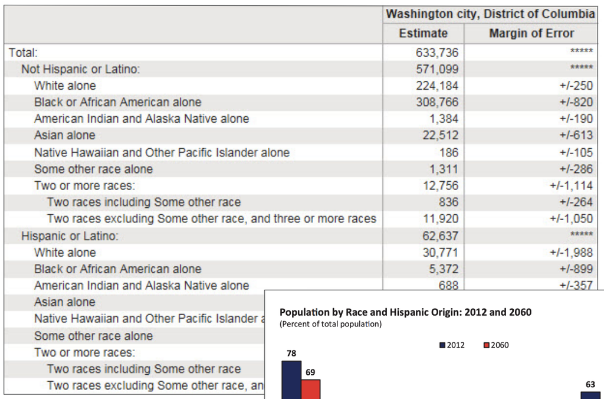

Pull all of the race/ethnicity counts for 2018.

```r
# variables of interest
vars <- c(
  # Hispanic or Latino
  "DP05_0071E", # Estimate!!HISPANIC OR LATINO AND RACE!!Total population!!Hispanic or Latino (of any race)
  "DP05_0071M",
  # Not Hispanic or Latino
  "DP05_0077E", # White alone
  "DP05_0077M",
  "DP05_0078E", # Black or African American alone
  "DP05_0078M",
  "DP05_0079E", # American Indian and Alaska Native alone
  "DP05_0079M",
  "DP05_0080E", # Asian alone
  "DP05_0080M",
  "DP05_0081E", # Native Hawaiian and Other Pacific Islander alone
  "DP05_0081M",
  "DP05_0082E", # Some other race alone
  "DP05_0082M",
  "DP05_0083E", # Two or more races
  "DP05_0083M"
)

# pull Census tracts for 2018
tracts <- get_vars(year = 2018, vars = vars, geography = "tract")

# rename the variables
tracts <- tracts %>%
  rename(
    people = B01003_001E,
    hispanic = DP05_0071E,
    hispanic_moe = DP05_0071M,
    white_nh = DP05_0077E,
    white_nh_moe = DP05_0077M,
    black_nh = DP05_0078E,
    black_nh_moe = DP05_0078M,
    aian_nh = DP05_0079E,
    aian_nh_moe = DP05_0079M,
    asian_nh = DP05_0080E,
    asian_nh_moe = DP05_0080M,
    nhpi_nh = DP05_0081E,
    nhpi_nh_moe = DP05_0081M,
    other_nh = DP05_0082E,
    other_nh_moe = DP05_0082M,
    two_or_more_nh = DP05_0083E,
    two_or_more_nh_moe = DP05_0083M
  )
```

### 2. Collapse the detailed groups to the three groups of interest.

Non-Hispanic American Indian and Alaska Native alone (`aian_nh`), Non-Hispanic Asian alone (`asian_nh`), non-Hispanic Native Hawaiian and Other Pacific Island alone (`nhpi_nh`), non-Hispanic other (`other_nh`), non-Hispanic two or more (`two_or_more_nh`) are collapsed into non-Hispanic white.

```r
tracts <- tracts %>%
  mutate(white_nh = white_nh +
           aian_nh +
           asian_nh +
           nhpi_nh +
           other_nh +
           two_or_more_nh) %>%
  select(state, county, people, hispanic, black_nh, white_nh)
```

**Check:** Do the pulled race/ethnicity counts sum to the tract populations?

```r
stopifnot(
  tracts %>%
    mutate(people2 = hispanic + black_nh + white_nh) %>%
    filter(people != people2) %>%
    nrow() == 0
)
```

### 3. Calculate the share of a county’s racial/ethnic group in each tract

```r
indices <- tracts %>%
  group_by(state, county) %>%
  mutate(
    share_of_white_nh = white_nh / sum(white_nh),
    share_of_black_nh = black_nh / sum(black_nh),
    share_of_hispanic = hispanic / sum(hispanic)
    ) %>%
  ungroup()
```

**Check:** Do the shares in each tract sum to one in a county?

```r
stopifnot(
  indices %>%
    group_by(state, county) %>%
    summarize(
      share_of_white_nh = sum(share_of_white_nh),
      share_of_black_nh = sum(share_of_black_nh),
      share_of_hispanic = sum(share_of_hispanic)
    ) %>%
    filter(!near(share_of_white_nh, 1) | !near(share_of_black_nh, 1) | !near(share_of_hispanic, 1)) %>%
    nrow() == 0
)
```

### 4. Calculate exposure to other racial/ethnic groups

- Calculate non-Hispanic white exposure to non-Hispanic black and Hispanic.
- Calculate non-Hispanic black exposure to non-Hispanic white and Hispanic.
- Calculate Hispanic exposure to non-Hispanic white and non-Hispanic black.

Calculate the complement to each race/ethnic group of interest.

```r
indices <- indices %>%
  mutate(
    non_white_nh = (hispanic + black_nh) / people,
    non_black_nh = (hispanic + white_nh) / people,
    non_hispanic = (white_nh + black_nh) / people
    )
```

```r
indices <- indices %>%
  group_by(state, county) %>%
  summarize(
    people = sum(people),
    hispanic = sum(hispanic),
    black_nh = sum(black_nh),
    white_nh = sum(white_nh),
    white_nh_exposure = weighted.mean(non_white_nh, w = share_of_white_nh),
    black_nh_exposure = weighted.mean(non_black_nh, w = share_of_black_nh),
    hispanic_exposure = weighted.mean(non_hispanic, w = share_of_hispanic)
    ) %>%
  ungroup()
```

### 5. Validation

The table shows the calculated metrics. Click on the variable columns to sort the table.

| FIPS | white_nh | black_nh | hispanic | white_nh_exp | black_nh_exp | hispanic_exp |
| --- | --- | --- | --- | --- | --- | --- |
| 01001 | 43197 | 10475 | 1528 | 0.2 | 0.74 | 0.929 |
| 01003 | 179225 | 19529 | 9353 | 0.127 | 0.8 | 0.924 |
| 01005 | 12477 | 12199 | 1106 | 0.486 | 0.49 | 0.935 |
| 01007 | 17006 | 4974 | 547 | 0.193 | 0.615 | 0.964 |
| 01009 | 51564 | 820 | 5261 | 0.099 | 0.97 | 0.852 |
| 01011 | 2408 | 7893 | 51 | 0.687 | 0.213 | 0.994 |
| 01013 | 10931 | 9027 | 67 | 0.371 | 0.448 | 0.991 |
| 01015 | 87277 | 23618 | 4203 | 0.19 | 0.607 | 0.909 |
| 01017 | 19739 | 13319 | 768 | 0.381 | 0.558 | 0.948 |
| 01019 | 24188 | 1267 | 398 | 0.064 | 0.939 | 0.979 |

[output cut: 3132 more lines]

**Check:** Do groups with zero representation in a county have an `NA` for the exposure metric?

```r
stopifnot(
  indices %>%
    filter(white_nh == 0 & !is.na(white_nh_exposure)) %>%
    nrow() == 0
)

stopifnot(
  indices %>%
    filter(black_nh == 0 & !is.na(black_nh_exposure)) %>%
    nrow == 0
)

stopifnot(
  indices %>%
    filter(hispanic == 0 & !is.na(hispanic_exposure)) %>%
    nrow() == 0
)
```

**Check:** How many missing values are there?

```r
map_dbl(indices, ~sum(is.na(.)))
```

```
##             state            county            people          hispanic
##                 0                 0                 0                 0
##          black_nh          white_nh white_nh_exposure black_nh_exposure
##                 0                 0                 0                96
## hispanic_exposure
##                14
```

Let’s visualize the relationship between a group’s share of the population in a county and the calculated exposure metric.

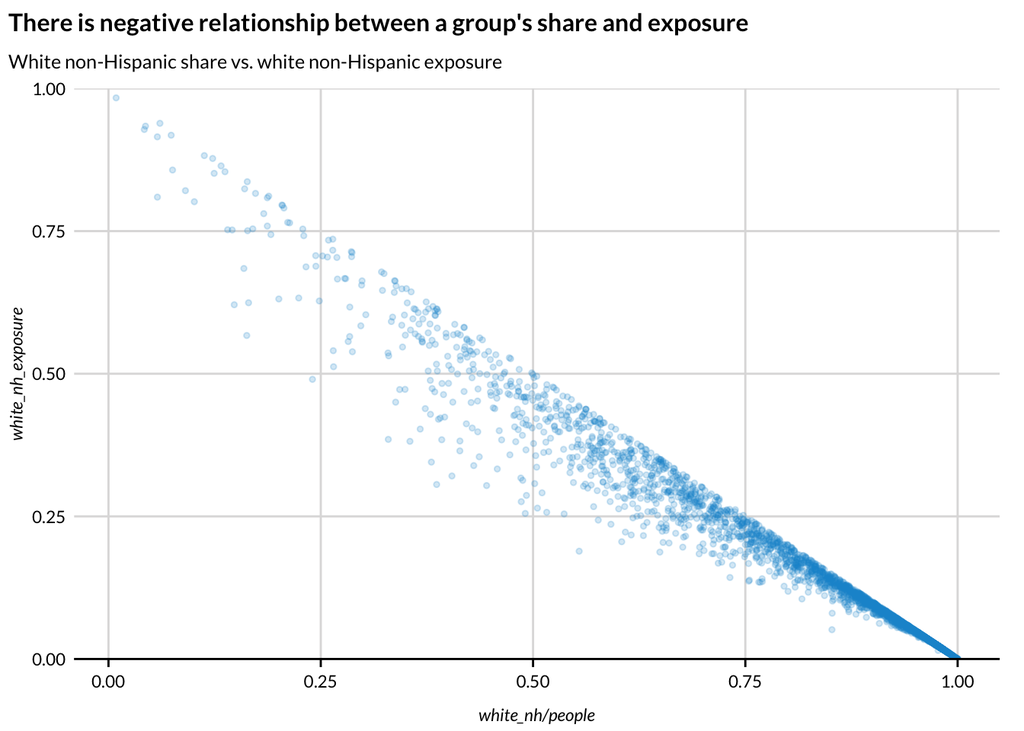

```r
indices %>%
  ggplot(aes(white_nh / people, white_nh_exposure)) +
  geom_point(alpha = 0.2,
             size = 1) +
  scale_y_continuous(expand = c(0, 0),
                     limits = c(0, 1)) +
  labs(title = "There is negative relationship between a group's share and exposure",
       subtitle = "White non-Hispanic share vs. white non-Hispanic exposure") +
  scatter_grid()
```

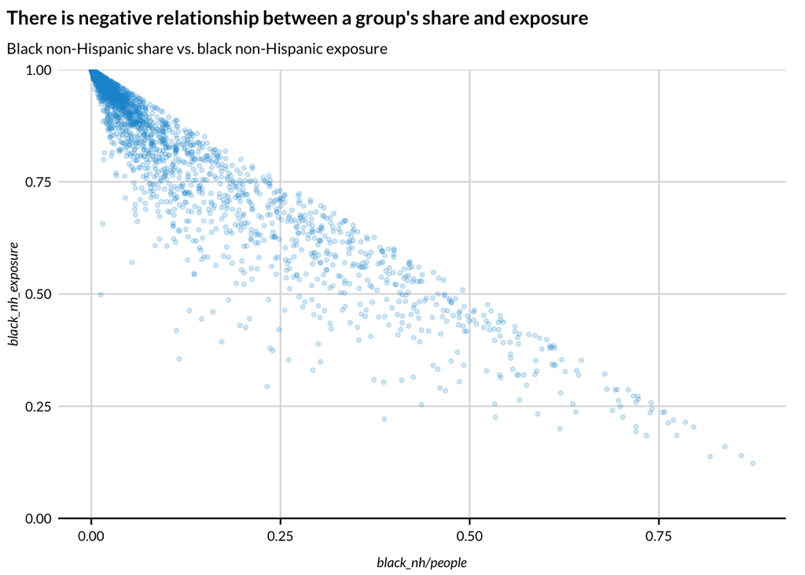

```r
indices %>%
  ggplot(aes(black_nh / people, black_nh_exposure)) +
  geom_point(alpha = 0.2,
             size = 1) +
  scale_y_continuous(expand = c(0, 0),
                     limits = c(0, 1)) +
  labs(title = "There is negative relationship between a group's share and exposure",
       subtitle = "Black non-Hispanic share vs. black non-Hispanic exposure") +
  scatter_grid()
```

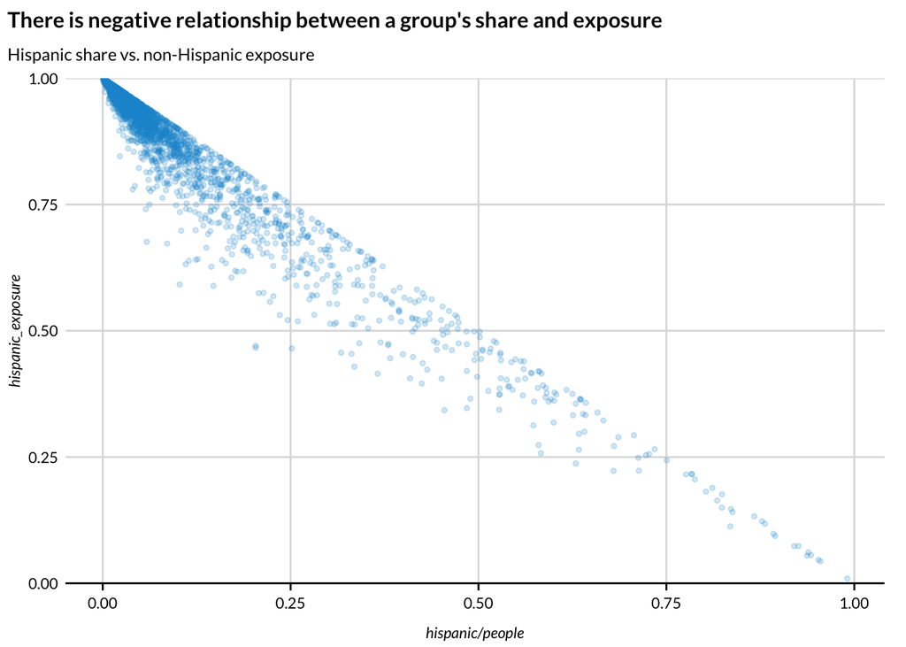

```r
indices %>%
  ggplot(aes(hispanic / people, hispanic_exposure)) +
  geom_point(alpha = 0.2,
             size = 1) +
  scale_y_continuous(expand = c(0, 0),
                     limits = c(0, 1)) +
  labs(title = "There is negative relationship between a group's share and exposure",
       subtitle = "Hispanic share vs. non-Hispanic exposure") +
  scatter_grid()
```

### 6. Outstanding questions

- Where should we put “American Indian and Alaska Native alone”, “Native Hawaiian and Other Pacific Islander alone”, “Some other race alone”, and “Two or more races”?
- The metric is `NA` for any race that has zero representation in a county. What should we do about counties with one or a few people in a racial/ethnic group?
- What geographic information are we using the join the data?
- For earlier years, do I only pull non-overlapping 5-year estimates?
- How should we account for uncertainty? Should I calculate coefficients of variation before calculating the metric?